# Praktikum MPDW: Pemodelan ARIMA Harga Emas Bulanan (1980-2025)

Daffa Faaiz Al-Zakkii | M0401241027

01 October 2026

```r
knitr::opts_chunk$set(echo = TRUE, message = FALSE, warning = FALSE,
                      fig.align = "center", fig.width = 9, fig.height = 5)

library(readxl)
library(forecast)
library(tseries)
library(lmtest)
library(knitr)
pf  <- function(p) ifelse(p < 0.001, "< 0,001", format(round(p, 4), decimal.mark = ","))
fm  <- function(x, d = 2) format(round(x, d), decimal.mark = ",", big.mark = ".")
kes <- function(p, alpha = 0.05) ifelse(p > alpha, "Terpenuhi", "Tidak terpenuhi")
kat_mape <- function(m) {
  if (m < 10) "sangat baik" else if (m < 20) "baik" else if (m < 50) "cukup (layak)" else "kurang baik"
}
```

# 1 Pendahuluan

Tugas memuat pemodelan **ARIMA (Autoregressive Integrated Moving Average)** pada data **harga emas dunia bulanan** (USD per troy ounce) periode Januari 1980 sampai Desember 2025. Tahapan yang dilakukan:

1. Pembagian data latih (*train*) dan data uji (*test*)
2. Pemeriksaan kestasioneran data latih dalam rataan (plot ACF dan uji ADF) dan dalam ragam (Box-Cox)
3. Penanganan ketidakstasioneran (transformasi untuk ragam, *differencing* untuk rataan)
4. Identifikasi model potensial (ACF, PACF, EACF)
5. Pendugaan parameter, uji signifikansi, dan perbandingan AIC
6. Analisis sisaan
7. *Overfitting*
8. Peramalan

# 2 Data

```r
dat <- read_excel("harga_emas_bulanan_1980_2025.xlsx")
colnames(dat) <- c("Periode", "Harga")
dat$Periode <- as.character(dat$Periode)

n_total <- nrow(dat)
emas <- ts(dat$Harga, start = c(1980, 1), frequency = 12)

kable(head(dat, 10), caption = "Sepuluh amatan pertama")
```

Sepuluh amatan pertama

| Periode | Harga |
| --- | --- |
| 1980-01 | 675 |
| 1980-02 | 665 |
| 1980-03 | 554 |
| 1980-04 | 517 |
| 1980-05 | 514 |
| 1980-06 | 601 |
| 1980-07 | 643 |
| 1980-08 | 627 |
| 1980-09 | 674 |
| 1980-10 | 661 |

```r
summary(dat$Harga)
```

```
##    Min. 1st Qu.  Median    Mean 3rd Qu.    Max.
##   256.0   363.8   447.5   859.2  1281.9  4309.0
```

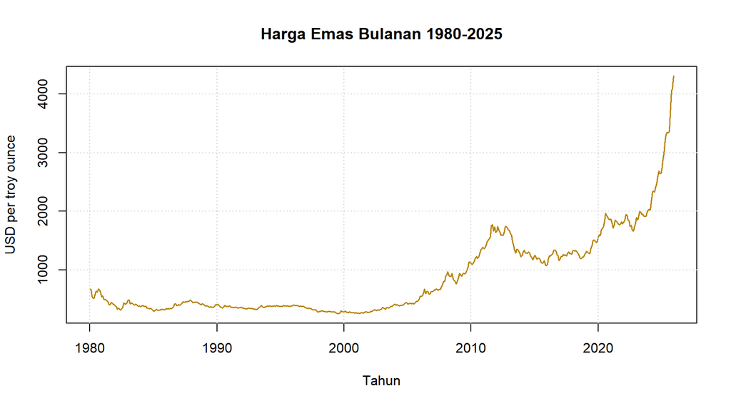

```r
plot(emas, type = "l", col = "darkgoldenrod", lwd = 1.5,
     main = "Harga Emas Bulanan 1980-2025",
     xlab = "Tahun", ylab = "USD per troy ounce")
grid()
```

**Interpretasi.** Data terdiri dari **552 amatan** bulanan (memenuhi syarat minimal 500 amatan). Harga terendah sebesar **256 USD** (1999-07) dan tertinggi **4.309 USD** (2025-12). Dari plot terlihat data tidak berfluktuasi di sekitar satu nilai tengah yang tetap: harga relatif datar di level rendah selama puluhan tahun, kemudian naik tajam. Selain itu, simpangan fluktuasi tampak membesar ketika levelnya naik. Hal ini mengindikasikan data **belum stasioner dalam rataan maupun ragam**, yang akan diuji secara formal pada tahap berikutnya.

# 3 Tahap 1: Pembagian Data Latih dan Data Uji

Data dibagi secara kronologis (tidak diacak, karena data deret waktu): amatan **Januari 1980 - Desember 2018** sebagai data latih (468 amatan) dan **Januari 2019 - Desember 2025** sebagai data uji (84 amatan, tujuh tahun penuh). Proporsi ini sekitar **85% : 15%**. Syarat minimal 500 amatan dipenuhi oleh keseluruhan data (552 amatan). Data uji dibuat cukup panjang agar kemampuan model meramal jangka menengah dapat dievaluasi dengan lebih adil; data latih tetap mencakup 39 tahun sehingga pola jangka panjang (termasuk periode kenaikan harga 2001-2011) sudah dipelajari model.

```r
n_train <- 468
train <- ts(dat$Harga[1:n_train], start = c(1980, 1), frequency = 12)
test  <- ts(dat$Harga[(n_train + 1):n_total], start = c(2019, 1), frequency = 12)

c(n_train = length(train), n_test = length(test),
  persen_train = round(100 * length(train) / n_total, 1))
```

```
##      n_train       n_test persen_train
##        468.0         84.0         84.8
```

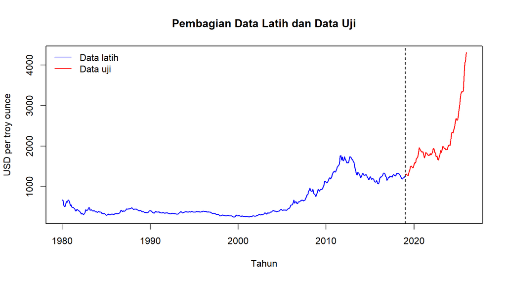

```r
plot(emas, type = "n", main = "Pembagian Data Latih dan Data Uji",
     xlab = "Tahun", ylab = "USD per troy ounce")
lines(train, col = "blue", lwd = 1.5)
lines(test,  col = "red",  lwd = 1.5)
abline(v = 2019, lty = 2)
legend("topleft", legend = c("Data latih", "Data uji"),
       col = c("blue", "red"), lty = 1, bty = "n")
```

**Interpretasi.** Data latih (biru) berisi 468 amatan dan data uji (merah) berisi 84 amatan. Perlu diperhatikan bahwa data uji memuat periode kenaikan harga yang sangat tajam (harga mencapai 4.309 USD), jauh di atas level tertinggi pada data latih (1.772 USD). Artinya, data uji berada di luar rentang pengalaman model, sehingga kita perlu berhati-hati dalam menilai akurasi peramalan pada tahap akhir.

# 4 Tahap 2: Eksplorasi Kestasioneran Data Latih

## 4.1 Kestasioneran dalam Rataan

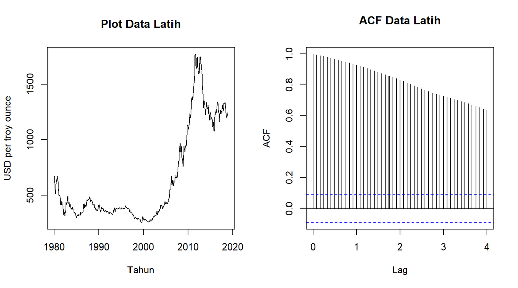

```r
par(mfrow = c(1, 2))
plot(train, main = "Plot Data Latih", xlab = "Tahun", ylab = "USD per troy ounce")
acf(train, lag.max = 48, main = "ACF Data Latih")
```

```r
par(mfrow = c(1, 1))

adf_train <- adf.test(train)
adf_train
```

```
##
##  Augmented Dickey-Fuller Test
##
## data:  train
## Dickey-Fuller = -2.1079, Lag order = 7, p-value = 0.5323
## alternative hypothesis: stationary
```

**Interpretasi.**

- **Plot deret waktu:** data tidak bergerak di sekitar nilai tengah yang konstan, melainkan menunjukkan pola tren naik.
- **Plot ACF:** nilai autokorelasi turun **sangat lambat** (*tails off slowly*) dan tetap berada di luar batas signifikansi (garis putus-putus biru) hingga lag-lag yang jauh. Pola ini merupakan ciri khas data yang tidak stasioner dalam rataan.
- **Uji ADF** (H0: data tidak stasioner; H1: data stasioner) menghasilkan *p-value* = **0,5323**. Karena *p-value* > 0,05, H0 gagal ditolak sehingga data **belum stasioner dalam rataan**, sejalan dengan plot deret waktu dan ACF.

## 4.2 Kestasioneran dalam Ragam (Box-Cox)

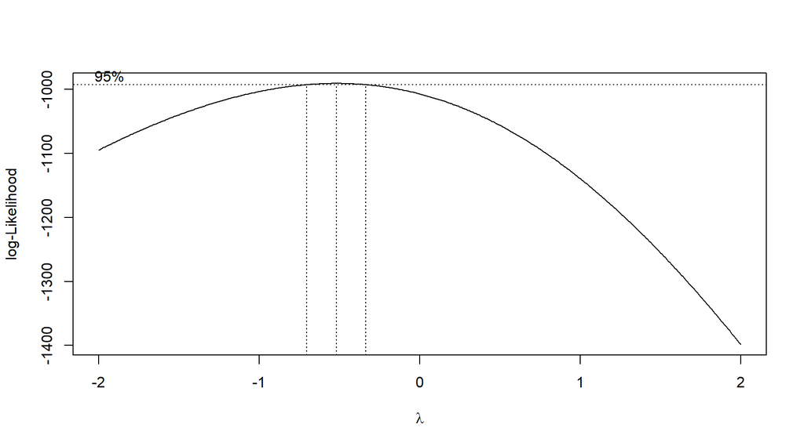

```r
idx <- seq_along(train)
bc <- MASS::boxcox(train ~ idx, lambda = seq(-2, 2, by = 0.01))
```

```r
lam_hat <- bc$x[which.max(bc$y)]
ci      <- bc$x[bc$y > max(bc$y) - 0.5 * qchisq(0.95, 1)]
ci_low  <- min(ci)
ci_up   <- max(ci)
mengandung_1 <- (ci_low <= 1 & ci_up >= 1)
mengandung_0 <- (ci_low <= 0 & ci_up >= 0)

data.frame(Lambda_optimum = lam_hat, Batas_bawah_95 = ci_low,
           Batas_atas_95 = ci_up, Memuat_1 = ifelse(mengandung_1, "Ya", "Tidak"))
```

| Lambda_optimum | Batas_bawah_95 | Batas_atas_95 | Memuat_1 |
| --- | --- | --- | --- |
| -0.52 | -0.7 | -0.34 | Tidak |

**Interpretasi.** Nilai lambda optimum adalah **-0,52** dengan selang kepercayaan 95% sebesar **[-0,7; -0,34]**. Selang ini **tidak memuat angka 1, sehingga data** belum stasioner dalam ragam** dan perlu ditransformasi.** Selang tidak memuat angka 0 maupun 1, sehingga transformasi Box-Cox dengan lambda optimum digunakan.

# 5 Tahap 3: Penanganan Ketidakstasioneran

## 5.1 Transformasi untuk Menstabilkan Ragam

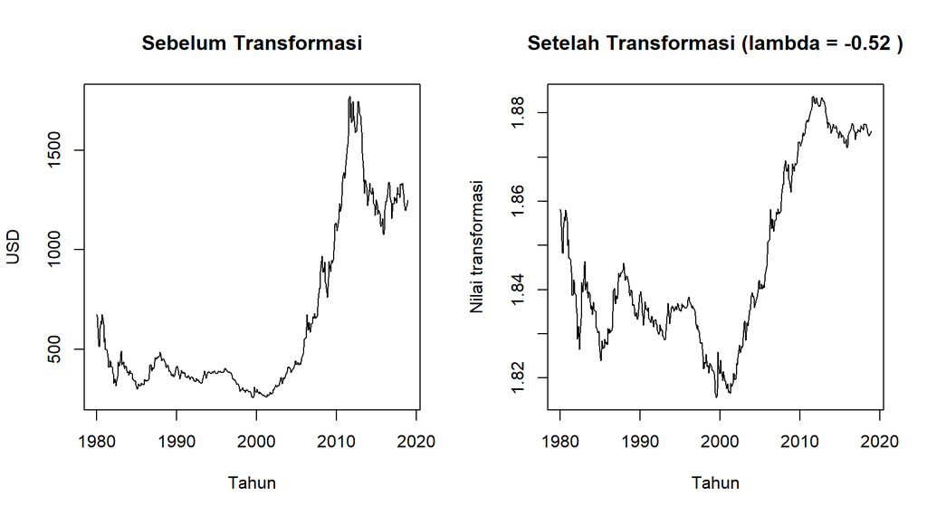

```r
if (mengandung_1) {
  lambda_pakai <- 1
} else if (mengandung_0) {
  lambda_pakai <- 0
} else {
  lambda_pakai <- round(lam_hat, 2)
}
lam_arg  <- if (lambda_pakai == 1) NULL else lambda_pakai
train_tr <- if (lambda_pakai == 1) train else BoxCox(train, lambda_pakai)

par(mfrow = c(1, 2))
plot(train,    main = "Sebelum Transformasi", xlab = "Tahun", ylab = "USD")
plot(train_tr, main = paste("Setelah Transformasi (lambda =", lambda_pakai, ")"),
     xlab = "Tahun", ylab = "Nilai transformasi")
```

```r
par(mfrow = c(1, 1))
```

**Interpretasi.** Transformasi yang digunakan adalah **lambda = -0.52**. Pada plot sebelah kanan, fluktuasi pada level harga yang tinggi tidak lagi jauh lebih besar dibandingkan pada level rendah (variasi relatif lebih seragam sepanjang waktu), dibandingkan data asli di sebelah kiri yang simpangannya melebar. Tren naik masih tampak, sehingga masalah kestasioneran **dalam rataan** belum teratasi dan ditangani dengan *differencing*.

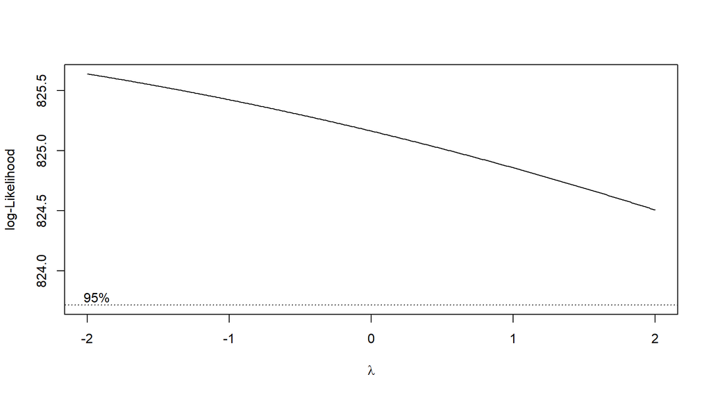

```
## batas_bawah  batas_atas
##          -2           2
```

```r
if (lambda_pakai != 1 && all(train_tr > 0)) {
  bc2 <- MASS::boxcox(train_tr ~ idx, lambda = seq(-2, 2, by = 0.01))
  ci2 <- bc2$x[bc2$y > max(bc2$y) - 0.5 * qchisq(0.95, 1)]
  ci2_low <- min(ci2); ci2_up <- max(ci2)
  c(batas_bawah = ci2_low, batas_atas = ci2_up)
}
```

**Interpretasi.** Pemeriksaan Box-Cox ulang pada data hasil transformasi menghasilkan selang **[-2; 2]**. Selang sudah memuat angka 1, sehingga ragam data setelah transformasi dapat dianggap stasioner.

## 5.2 Differencing untuk Menstabilkan Rataan

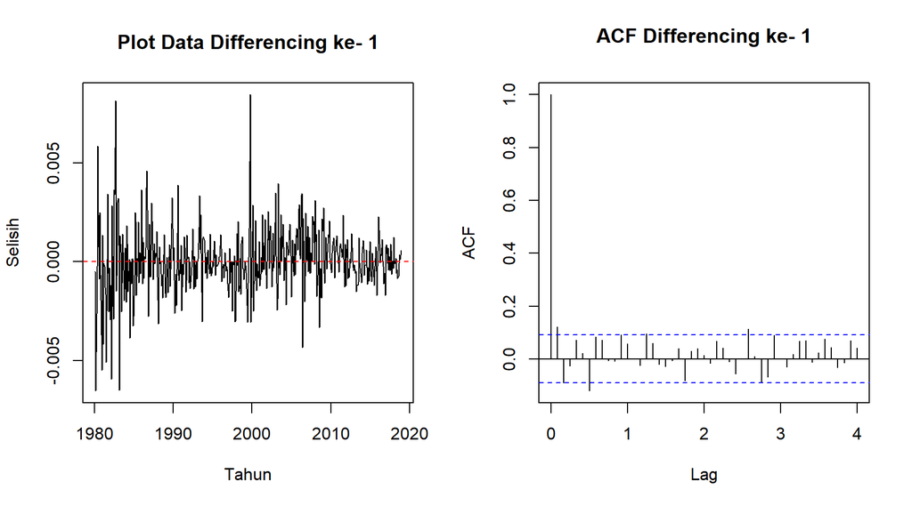

```r
adf_tr <- adf.test(train_tr)

diff1 <- diff(train_tr, differences = 1)
adf_d1 <- adf.test(diff1)

d_pakai <- if (adf_d1$p.value < 0.05) 1 else 2
train_diff <- diff(train_tr, differences = d_pakai)
adf_d <- adf.test(train_diff)

par(mfrow = c(1, 2))
plot(train_diff, main = paste("Plot Data Differencing ke-", d_pakai),
     xlab = "Tahun", ylab = "Selisih")
abline(h = 0, col = "red", lty = 2)
acf(train_diff, lag.max = 48, main = paste("ACF Differencing ke-", d_pakai))
```

```r
par(mfrow = c(1, 1))

data.frame(Data = c("Hasil transformasi", "Differencing ke-1", paste("Differencing ke-", d_pakai)),
           p_value_ADF = c(adf_tr$p.value, adf_d1$p.value, adf_d$p.value))
```

| Data | p_value_ADF |
| --- | --- |
| Hasil transformasi | 0.40826 |
| Differencing ke-1 | 0.01000 |
| Differencing ke- 1 | 0.01000 |

**Interpretasi.** Uji ADF pada data hasil transformasi (sebelum *differencing*) memberikan *p-value* **0,4083**, yang menunjukkan data masih belum stasioner dalam rataan. Setelah dilakukan *differencing* ke-1, *p-value* ADF menjadi **0,01**; H0 ditolak sehingga data hasil differencing sudah stasioner dalam rataan. Dengan demikian digunakan **d = 1**. Pada plot, data hasil *differencing* berfluktuasi di sekitar nol (garis merah) dan ACF tidak lagi meluruh lambat, yang mengonfirmasi kestasioneran dalam rataan. Nilai **d = 1** dipakai untuk seluruh model ARIMA selanjutnya.

# 6 Tahap 4: Identifikasi Model Potensial

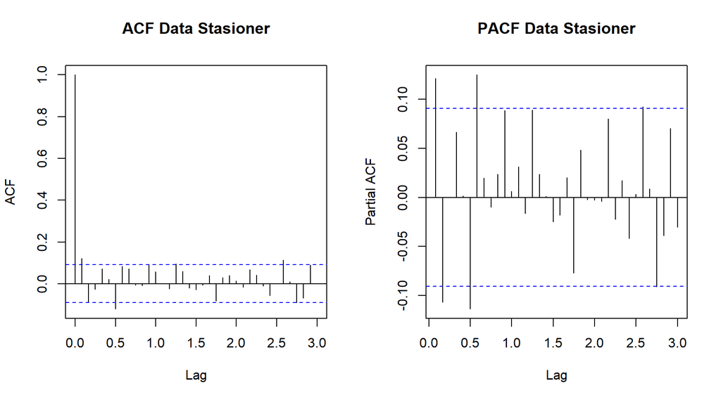

```r
par(mfrow = c(1, 2))
acf(train_diff,  lag.max = 36, main = "ACF Data Stasioner")
pacf(train_diff, lag.max = 36, main = "PACF Data Stasioner")
```

```r
par(mfrow = c(1, 1))

batas <- qnorm(0.975) / sqrt(length(train_diff))
a_val <- acf(train_diff,  lag.max = 36, plot = FALSE)$acf[-1]
p_val <- pacf(train_diff, lag.max = 36, plot = FALSE)$acf
sig_acf  <- which(abs(a_val) > batas)
sig_pacf <- which(abs(p_val) > batas)
txt_acf  <- if (length(sig_acf)  == 0) "tidak ada lag" else paste0("lag ", paste(head(sig_acf, 10),  collapse = ", "))
txt_pacf <- if (length(sig_pacf) == 0) "tidak ada lag" else paste0("lag ", paste(head(sig_pacf, 10), collapse = ", "))
```

**Interpretasi.**

- **ACF** yang melewati batas signifikansi (+/- 0,091): **lag 1, 6, 11, 15, 31**. Jika ACF terpotong (*cuts off*) setelah lag ke-q, model yang dicurigai adalah MA(q).
- **PACF** yang melewati batas signifikansi: **lag 1, 2, 6, 7, 31, 33**. Jika PACF terpotong setelah lag ke-p, model yang dicurigai adalah AR(p).
- Jika keduanya meluruh (*tails off*), model campuran ARMA(p,q) dicurigai. Lag signifikan yang muncul sporadis pada lag jauh (misalnya lag musiman) cenderung kebetulan dan bukan dasar utama pemilihan orde.

```r
TSA::eacf(as.numeric(train_diff), ar.max = 6, ma.max = 6)
```

```
## AR/MA
##   0 1 2 3 4 5 6
## 0 x o o o o x o
## 1 x x o o o o x
## 2 o x o o o o x
## 3 o x x o o o x
## 4 o x x x o o o
## 5 o x o x x o o
## 6 x x o x o o o
```

**Interpretasi EACF.** Pada tabel EACF, simbol **o** berarti nilai tidak signifikan dan **x** berarti signifikan. Model dugaan ditentukan dari **pojok kiri atas segitiga simbol “o”**; baris menunjukkan orde AR (p) dan kolom menunjukkan orde MA (q). Titik pojok segitiga tersebut menjadi calon ARMA(p,q), dan model tetangganya (p+1 atau q+1) juga dapat dipertimbangkan.

Berdasarkan ACF, PACF, dan EACF di atas, serta mempertimbangkan model-model tetangga sederhana, ditetapkan beberapa model potensial di bawah ini. **Daftar `kandidat` dapat disesuaikan** jika hasil ACF/PACF/EACF pada data Anda menunjukkan orde lain.

```r
d <- d_pakai
kandidat <- list(
  c(1, d, 0), c(0, d, 1), c(1, d, 1),
  c(2, d, 0), c(0, d, 2), c(2, d, 1), c(1, d, 2)
)
nama_model <- sapply(kandidat, function(o) sprintf("ARIMA(%d,%d,%d)", o[1], o[2], o[3]))
nama_model
```

```
## [1] "ARIMA(1,1,0)" "ARIMA(0,1,1)" "ARIMA(1,1,1)" "ARIMA(2,1,0)" "ARIMA(0,1,2)"
## [6] "ARIMA(2,1,1)" "ARIMA(1,1,2)"
```

# 7 Tahap 5: Pendugaan Parameter, Uji Signifikansi, dan AIC

Setiap model potensial diduga dengan metode *maximum likelihood* pada data latih (dengan transformasi yang sama). Parameter diuji dengan uji Wald/z (H0: parameter = 0; H1: parameter != 0) pada taraf nyata 5%.

```r
fit_arima <- function(ord) {
  tryCatch(Arima(train, order = ord, lambda = lam_arg, method = "ML"),
           error = function(e) NULL)
}
models <- lapply(kandidat, fit_arima)
names(models) <- nama_model

for (nm in nama_model[!sapply(models, is.null)]) {
  cat("\n==============", nm, "==============\n")
  print(coeftest(models[[nm]]))
}
```

```
##
## ============== ARIMA(1,1,0) ==============
##
## z test of coefficients:
##
##     Estimate Std. Error z value Pr(>|z|)
## ar1 0.121794   0.045883  2.6544 0.007945 **
## ---
## Signif. codes:  0 '***' 0.001 '**' 0.01 '*' 0.05 '.' 0.1 ' ' 1
##
##
## ============== ARIMA(0,1,1) ==============
##
## z test of coefficients:
##
##     Estimate Std. Error z value Pr(>|z|)
## ma1 0.148717   0.049478  3.0057 0.002649 **
## ---
## Signif. codes:  0 '***' 0.001 '**' 0.01 '*' 0.05 '.' 0.1 ' ' 1
##
##
## ============== ARIMA(1,1,1) ==============
##
## z test of coefficients:
##
##     Estimate Std. Error z value Pr(>|z|)
## ar1 -0.35574    0.35902 -0.9909   0.3218
## ma1  0.49691    0.33707  1.4742   0.1404
##
##
## ============== ARIMA(2,1,0) ==============
##
## z test of coefficients:
##
##      Estimate Std. Error z value Pr(>|z|)
## ar1  0.134849   0.045967  2.9336 0.003351 **
## ar2 -0.109052   0.046718 -2.3343 0.019582 *
## ---
## Signif. codes:  0 '***' 0.001 '**' 0.01 '*' 0.05 '.' 0.1 ' ' 1
##
```

[output cut: 17 more lines]

```
## ar1  0.137569   0.286519  0.4801  0.63113
## ar2 -0.109405   0.058163 -1.8810  0.05997 .
## ma1 -0.002815   0.286160 -0.0098  0.99215
## ---
## Signif. codes:  0 '***' 0.001 '**' 0.01 '*' 0.05 '.' 0.1 ' ' 1
##
##
## ============== ARIMA(1,1,2) ==============
##
## z test of coefficients:
##
##      Estimate Std. Error z value Pr(>|z|)
## ar1  0.171654   0.382153  0.4492   0.6533
## ma1 -0.037208   0.379171 -0.0981   0.9218
## ma2 -0.103119   0.065793 -1.5673   0.1170
```

```r
ringkas <- function(m, nm) {
  ct <- coeftest(m)
  data.frame(Model = nm,
             Jumlah_parameter = nrow(ct),
             AIC = round(m$aic, 2),
             BIC = round(m$bic, 2),
             Semua_signifikan = ifelse(all(ct[, 4] < 0.05), "Ya", "Tidak"))
}
ok  <- !sapply(models, is.null)
tab <- do.call(rbind, Map(ringkas, models[ok], names(models)[ok]))
tab <- tab[order(tab$AIC), ]
rownames(tab) <- NULL
kable(tab, caption = "Perbandingan model potensial (diurutkan berdasarkan AIC)")
```

Perbandingan model potensial (diurutkan berdasarkan AIC)

| Model | Jumlah_parameter | AIC | BIC | Semua_signifikan |
| --- | --- | --- | --- | --- |
| ARIMA(2,1,0) | 2 | -4674.00 | -4661.56 | Ya |
| ARIMA(0,1,2) | 2 | -4673.14 | -4660.70 | Tidak |
| ARIMA(0,1,1) | 1 | -4672.20 | -4663.91 | Ya |
| ARIMA(1,1,1) | 2 | -4672.07 | -4659.64 | Tidak |
| ARIMA(2,1,1) | 3 | -4672.00 | -4655.41 | Tidak |
| ARIMA(1,1,2) | 3 | -4671.34 | -4654.76 | Tidak |
| ARIMA(1,1,0) | 1 | -4670.58 | -4662.29 | Ya |

```r
kand_sig  <- tab[tab$Semua_signifikan == "Ya", ]
best_name <- if (nrow(kand_sig) > 0) kand_sig$Model[which.min(kand_sig$AIC)] else tab$Model[1]
best      <- models[[best_name]]
ord_best  <- c(best$arma[1], best$arma[6], best$arma[2])   # p, d, q
```

**Interpretasi.** Dari 7 model yang berhasil diduga, terdapat **3 model** dengan seluruh parameter signifikan pada taraf 5%. Pemilihan model terbaik dilakukan dengan kriteria: **semua parameter signifikan** dan **AIC terkecil** (semakin kecil AIC, semakin baik keseimbangan antara kecocokan dan kesederhanaan model). Model terpilih adalah **ARIMA(2,1,0)** dengan AIC = **-4.674**. Berikut ringkasan model terpilih:

```r
summary(best)
```

```
## Series: train
## ARIMA(2,1,0)
## Box Cox transformation: lambda= -0.52
##
## Coefficients:
##          ar1      ar2
##       0.1348  -0.1091
## s.e.  0.0460   0.0467
##
## sigma^2 = 2.62e-06:  log likelihood = 2340
## AIC=-4674   AICc=-4673.95   BIC=-4661.56
##
## Training set error measures:
##                    ME     RMSE      MAE        MPE     MAPE      MASE
## Training set 1.261807 29.72481 19.09263 0.05724183 2.916353 0.2338926
##                    ACF1
## Training set 0.04242425
```

**Interpretasi.** Koefisien model terpilih ada pada skala data yang telah ditransformasi (lambda = -0.52) dan telah di-*differencing* sebanyak d = 1 kali. Nilai *standard error* yang kecil relatif terhadap koefisien menunjukkan pendugaan parameter yang cukup presisi. Ukuran kesalahan pada bagian *Training set* menunjukkan kualitas kecocokan model pada data latih saja; kualitas peramalan sebenarnya dinilai pada data uji di Tahap 8.

# 8 Tahap 6: Analisis Sisaan

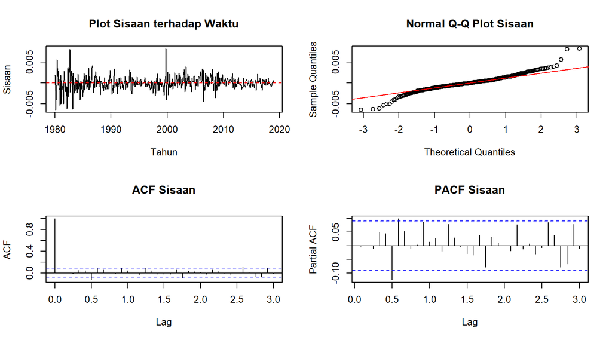

```r
res <- residuals(best)

par(mfrow = c(2, 2))
plot(res, main = "Plot Sisaan terhadap Waktu", ylab = "Sisaan", xlab = "Tahun")
abline(h = 0, col = "red", lty = 2)
qqnorm(res, main = "Normal Q-Q Plot Sisaan"); qqline(res, col = "red")
acf(res,  lag.max = 36, main = "ACF Sisaan")
pacf(res, lag.max = 36, main = "PACF Sisaan")
```

```r
par(mfrow = c(1, 1))
```

**Interpretasi.**

- **Plot sisaan vs waktu:** sisaan yang baik berfluktuasi acak di sekitar nol dengan sebaran yang kurang lebih sama sepanjang waktu. Jika terlihat periode dengan simpangan yang lebih besar (*volatility clustering*), ragam sisaan tidak homogen.
- **Normal Q-Q Plot:** sisaan dianggap menyebar normal bila titik-titik mengikuti garis merah. Penyimpangan pada ujung kiri/kanan menandakan ekor distribusi lebih tebal dari normal.
- **ACF dan PACF sisaan:** sisaan bebas autokorelasi bila hampir seluruh lag berada dalam batas signifikansi, artinya model sudah menangkap struktur ketergantungan dalam data.

```r
fitdf <- ord_best[1] + ord_best[3]
lb    <- Box.test(res, lag = 24, type = "Ljung-Box", fitdf = fitdf)
tt    <- t.test(as.numeric(res), mu = 0)
sw    <- shapiro.test(as.numeric(res))
jb    <- jarque.bera.test(as.numeric(res))
lb2   <- Box.test(res^2, lag = 12, type = "Ljung-Box")

tab_res <- data.frame(
  Asumsi = c("Tidak ada autokorelasi", "Nilai tengah sisaan = 0",
             "Sisaan menyebar normal", "Sisaan menyebar normal",
             "Ragam sisaan homogen"),
  Uji = c("Ljung-Box (lag 24)", "Uji-t satu sampel", "Shapiro-Wilk",
          "Jarque-Bera", "Ljung-Box pada sisaan kuadrat (lag 12)"),
  H0 = c("Tidak ada autokorelasi", "Rataan sisaan = 0",
         "Sisaan normal", "Sisaan normal", "Ragam homogen (tidak ada efek ARCH)"),
  p_value = c(lb$p.value, tt$p.value, sw$p.value, jb$p.value, lb2$p.value)
)
tab_res$Kesimpulan <- kes(tab_res$p_value)
tab_res$p_value    <- round(tab_res$p_value, 4)
kable(tab_res, caption = "Hasil uji asumsi sisaan (taraf nyata 5%)")
```

Hasil uji asumsi sisaan (taraf nyata 5%)

| Asumsi | Uji | H0 | p_value | Kesimpulan |
| --- | --- | --- | --- | --- |
| Tidak ada autokorelasi | Ljung-Box (lag 24) | Tidak ada autokorelasi | 0.0585 | Terpenuhi |
| Nilai tengah sisaan = 0 | Uji-t satu sampel | Rataan sisaan = 0 | 0.5818 | Terpenuhi |
| Sisaan menyebar normal | Shapiro-Wilk | Sisaan normal | 0.0000 | Tidak terpenuhi |
| Sisaan menyebar normal | Jarque-Bera | Sisaan normal | 0.0000 | Tidak terpenuhi |
| Ragam sisaan homogen | Ljung-Box pada sisaan kuadrat (lag 12) | Ragam homogen (tidak ada efek ARCH) | 0.0000 | Tidak terpenuhi |

**Interpretasi.**

- **Autokorelasi (Ljung-Box):** *p-value* = 0,0585. H0 tidak ditolak, sisaan tidak saling berkorelasi: model sudah menangkap pola ketergantungan dengan baik.
- **Nilai tengah nol (uji-t):** *p-value* = 0,5818. Rataan sisaan tidak berbeda nyata dari nol, sehingga model tidak bias secara sistematis.
- **Kenormalan (Shapiro-Wilk dan Jarque-Bera):** *p-value* masing-masing < 0,001 dan < 0,001. Sedikitnya satu uji menolak kenormalan sisaan. Pada data harga komoditas/keuangan hal ini umum terjadi karena adanya lonjakan harga ekstrem (ekor distribusi tebal). Kita tetap melanjutkan analisis dan menyadari bahwa selang prediksi berbasis normalitas bisa kurang akurat.
- **Homogenitas ragam (Ljung-Box pada sisaan kuadrat):** *p-value* = < 0,001. Ragam sisaan tidak homogen (terdapat efek heteroskedastisitas bersyarat). Hal ini menandakan ARIMA saja belum sepenuhnya menangkap pola volatilitas, dan model lanjutan seperti ARIMA-GARCH dapat dipertimbangkan sebagai pengembangan di luar cakupan praktikum ini.

# 9 Tahap 7: Overfitting

*Overfitting* dilakukan dengan menambah satu orde pada model terpilih (**ARIMA(2,1,0)**), yaitu menambah orde AR (p+1) dan orde MA (q+1) secara terpisah. Model terpilih dianggap sudah cukup bila parameter tambahan **tidak signifikan** dan/atau AIC tidak lebih baik.

```r
p0 <- ord_best[1]; d0 <- ord_best[2]; q0 <- ord_best[3]

cek_ov <- function(ord_baru, nama_param) {
  m <- tryCatch(Arima(train, order = ord_baru, lambda = lam_arg, method = "ML"),
                error = function(e) NULL)
  if (is.null(m)) return(NULL)
  ct <- coeftest(m)
  pv <- if (nama_param %in% rownames(ct)) ct[nama_param, 4] else NA
  data.frame(Model = sprintf("ARIMA(%d,%d,%d)", ord_baru[1], ord_baru[2], ord_baru[3]),
             AIC = round(m$aic, 2),
             Parameter_tambahan = nama_param,
             p_value = round(pv, 4),
             Signifikan = ifelse(!is.na(pv) & pv < 0.05, "Ya", "Tidak"),
             Selisih_AIC = round(m$aic - best$aic, 2))
}

ov_tab <- rbind(
  cek_ov(c(p0 + 1, d0, q0), paste0("ar", p0 + 1)),
  cek_ov(c(p0, d0, q0 + 1), paste0("ma", q0 + 1))
)
kable(ov_tab, caption = paste("Overfitting terhadap", best_name, "| AIC model terpilih =", round(best$aic, 2)))
```

Overfitting terhadap ARIMA(2,1,0) | AIC model terpilih = -4674

| Model | AIC | Parameter_tambahan | p_value | Signifikan | Selisih_AIC |
| --- | --- | --- | --- | --- | --- |
| ARIMA(3,1,0) | -4672 | ar3 | 0.9899 | Tidak | 2 |
| ARIMA(2,1,1) | -4672 | ma1 | 0.9922 | Tidak | 2 |

```r
ov_lebih_baik <- any(ov_tab$Signifikan == "Ya" & ov_tab$Selisih_AIC < 0)
```

**Interpretasi.** Kolom *Selisih_AIC* menunjukkan AIC model *overfitting* dikurangi AIC model terpilih; nilai **positif** berarti AIC model *overfitting* lebih besar (lebih buruk). Tidak ada model overfitting yang memiliki parameter tambahan signifikan sekaligus AIC lebih kecil. Dengan demikian **ARIMA(2,1,0) dipertahankan sebagai model akhir**; penambahan orde tidak memberikan perbaikan yang berarti.

# 10 Tahap 8: Peramalan

Model akhir **ARIMA(2,1,0)** digunakan untuk meramal 84 bulan ke depan (Januari 2019 - Desember 2025), lalu dibandingkan dengan data uji. Hasil ramalan otomatis dikembalikan ke skala semula (USD) dari skala transformasi. Sebagai pembanding digunakan metode *naive* (ramalan = nilai terakhir data latih).

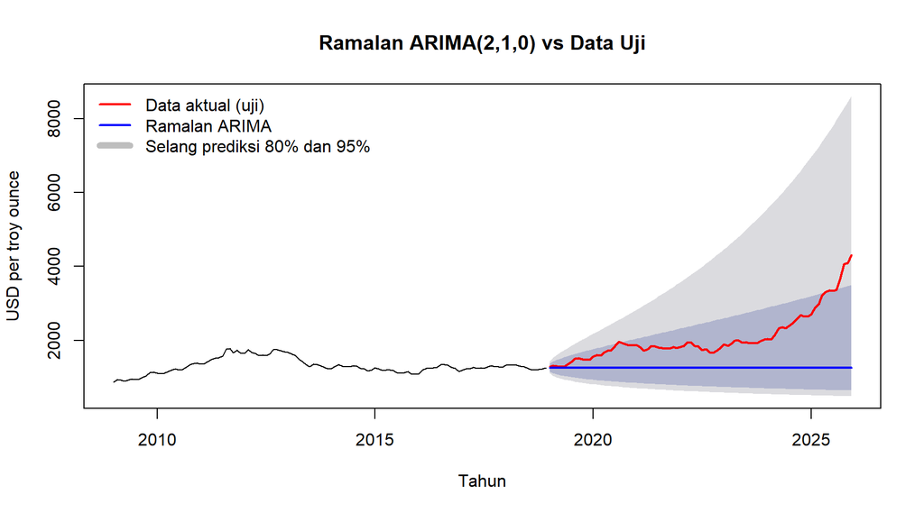

```r
h        <- length(test)
fc       <- forecast(best, h = h)
fc_naive <- naive(train, h = h)

ylim_fc <- range(c(tail(train, 120), test, fc$lower, fc$upper), na.rm = TRUE)
plot(fc, include = 120, ylim = ylim_fc,
     main = paste("Ramalan", best_name, "vs Data Uji"),
     xlab = "Tahun", ylab = "USD per troy ounce")
lines(test, col = "red", lwd = 2)
lines(fc$mean, col = "blue", lwd = 2)
legend("topleft", legend = c("Data aktual (uji)", "Ramalan ARIMA", "Selang prediksi 80% dan 95%"),
       col = c("red", "blue", "grey"), lwd = c(2, 2, 6), bty = "n")
```

**Interpretasi.** Garis biru adalah titik ramalan dan area abu-abu adalah selang prediksi 80% dan 95%. Garis merah adalah data aktual pada periode uji. Selang prediksi melebar seiring bertambahnya horizon peramalan, yang mencerminkan ketidakpastian yang meningkat. Pada model ARIMA dengan *differencing*, ramalan jangka panjang cenderung mendatar (tanpa tren) karena model tidak memuat komponen *drift*; sehingga jika harga aktual melonjak tajam seperti pada periode uji, ramalan akan tertinggal dari data aktual. Persentase data uji yang jatuh di dalam selang prediksi 95% adalah **100%**.

```r
akurasi <- rbind(
  ARIMA = accuracy(fc, test)[2, c("RMSE", "MAE", "MAPE")],
  Naive = accuracy(fc_naive, test)[2, c("RMSE", "MAE", "MAPE")]
)
kable(round(akurasi, 2), caption = "Akurasi peramalan pada data uji")
```

Akurasi peramalan pada data uji

|  | RMSE | MAE | MAPE |
| --- | --- | --- | --- |
| ARIMA | 1054.72 | 826.30 | 35.07 |
| Naive | 1054.78 | 826.43 | 35.08 |

```r
mape_arima <- akurasi["ARIMA", "MAPE"]
mape_naive <- akurasi["Naive", "MAPE"]
```

**Interpretasi.** Pada data uji, model **ARIMA(2,1,0)** menghasilkan **RMSE = 1.054,72**, **MAE = 826,3**, dan **MAPE = 35,07%**. Berdasarkan kriteria MAPE (< 10% sangat baik, 10-20% baik, 20-50% cukup, > 50% kurang baik), akurasi peramalan tergolong **cukup (layak)**. Dibandingkan metode *naive* (MAPE = 35,08%), model ARIMA memberikan galat yang lebih kecil sehingga lebih baik.

## 10.1 Peramalan 12 Bulan ke Depan (Tahun 2026)

```r
final_full <- Arima(emas, order = ord_best, lambda = lam_arg, method = "ML")
fc_next    <- forecast(final_full, h = 12)

tab_next <- data.frame(
  Periode = format(seq(as.Date("2026-01-01"), by = "month", length.out = 12), "%Y-%m"),
  Ramalan = round(as.numeric(fc_next$mean), 2),
  Batas_bawah_95 = round(as.numeric(fc_next$lower[, 2]), 2),
  Batas_atas_95  = round(as.numeric(fc_next$upper[, 2]), 2)
)
kable(tab_next, caption = "Ramalan harga emas 2026 (USD per troy ounce)")
```

Ramalan harga emas 2026 (USD per troy ounce)

| Periode | Ramalan | Batas_bawah_95 | Batas_atas_95 |
| --- | --- | --- | --- |
| 2026-01 | 4338.93 | 3489.56 | 5547.51 |
| 2026-02 | 4318.72 | 3132.53 | 6351.30 |
| 2026-03 | 4312.70 | 2936.01 | 6977.36 |
| 2026-04 | 4313.95 | 2794.13 | 7567.09 |
| 2026-05 | 4314.77 | 2675.60 | 8161.08 |
| 2026-06 | 4314.75 | 2573.54 | 8765.63 |
| 2026-07 | 4314.66 | 2484.61 | 9384.85 |
| 2026-08 | 4314.65 | 2405.94 | 10023.78 |
| 2026-09 | 4314.66 | 2335.38 | 10686.94 |
| 2026-10 | 4314.66 | 2271.44 | 11378.26 |
| 2026-11 | 4314.66 | 2213.01 | 12101.49 |
| 2026-12 | 4314.66 | 2159.25 | 12860.38 |

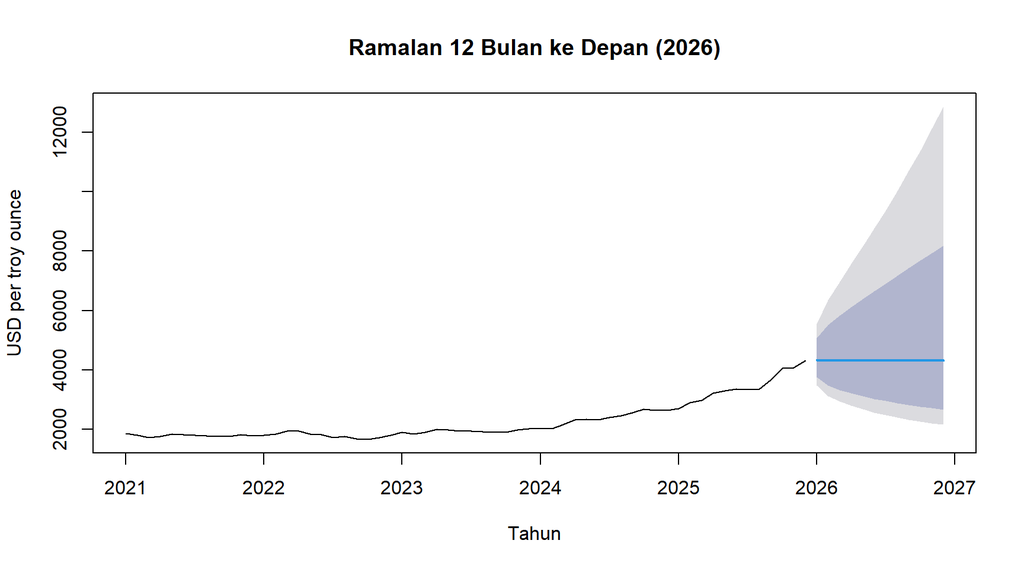

```r
plot(fc_next, include = 60, main = "Ramalan 12 Bulan ke Depan (2026)",
     xlab = "Tahun", ylab = "USD per troy ounce")
```

**Interpretasi.** Ramalan harga emas pada Desember 2026 adalah sekitar **4.314,66 USD** dengan selang prediksi 95% antara **2.159,25** dan **12.860,38 USD**. Lebarnya selang menunjukkan bahwa ketidakpastian ramalan cukup besar, sehingga hasil ini sebaiknya dipandang sebagai gambaran kecenderungan, bukan nilai pasti.

# 11 Kesimpulan

1. Data harga emas bulanan 1980-2025 (552 amatan) dibagi menjadi 468 data latih dan 84 data uji.
2. Data latih tidak stasioner dalam ragam (selang Box-Cox tidak memuat angka 1) dan dalam rataan (plot ACF meluruh lambat; *p-value* ADF = 0,5323). Penanganan: transformasi dengan lambda = -0.52 dan *differencing* sebanyak d = 1.
3. Dari beberapa model potensial, model terbaik berdasarkan signifikansi parameter dan AIC adalah **ARIMA(2,1,0)** (AIC = -4.674).
4. Analisis sisaan: autokorelasi **terpenuhi**, kenormalan **tidak terpenuhi** (Shapiro-Wilk), homogenitas ragam **tidak terpenuhi**.
5. Uji *overfitting* tidak menemukan model yang lebih baik, sehingga model terpilih dipertahankan.
6. Pada data uji, akurasi peramalan model memiliki **MAPE 35,07%** (kategori **cukup (layak)**).